# Client Report - Show me!

- Show All Code
- Hide All Code

Unit 4 Task 3

Author

```python
import polars as pl
import numpy as np
from lets_plot import *
from sklearn.model_selection import train_test_split
from sklearn import metrics
# add the additional libraries you need to import for ML here

LetsPlot.setup_html(isolated_frame=True)
```

```python
# import your data here using polars and the URL
df = pl.read_csv("../dwellings_ml.csv")
```

## QUESTION 1

1. **Repeat the classification exercise using 2 different algorithms/models. Explain the differences between the 3 models** (your original one, and the 2 new ones for this task).

*AI use reflection* **Link** to the original chat: https://chatgpt.com/s/cx_6af63f0607ac81919bb1729f1e4609f5 **The Process** How exactly did you use the tool? to tweak performance of classifiers and recommend other classifiers **The Impact** How did using AI impact your learning? It helped me find good classifier models to work with and tweak.

```python
# Include and execute your code here
from sklearn.ensemble import HistGradientBoostingClassifier
from sklearn.tree import DecisionTreeClassifier, ExtraTreeClassifier
from sklearn.ensemble import RandomForestClassifier
from sklearn.metrics import classification_report, confusion_matrix, ConfusionMatrixDisplay
from sklearn.inspection import permutation_importance
import polars.selectors as cs
```

```python
import warnings

warnings.filterwarnings(
    "ignore",
    message=r"X does not have valid feature names.*",
    category=UserWarning,
)
```

```python
# x = df.select(cs.numeric().exclude(["before1980","yrbuilt", "syear"]))
x= df.select(["gartype_Att", "quality_C", "stories", "numbaths","arcstyle_ONE-STORY","abstrprd","livearea","basement","nocars"])
y = df.select("before1980")

x_train, x_test, y_train, y_test = train_test_split(x, y, test_size=0.2, random_state=28)
```

```
              precision    recall  f1-score   support

           0       0.88      0.91      0.90      1753
           1       0.94      0.93      0.93      2830

    accuracy                           0.92      4583
   macro avg       0.91      0.92      0.92      4583
weighted avg       0.92      0.92      0.92      4583
```

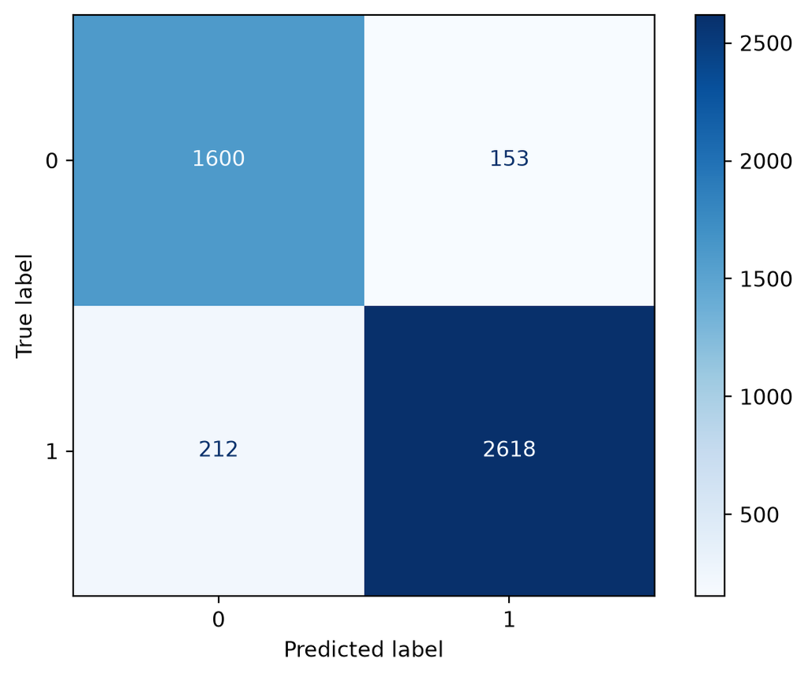

```python
dt_classifier = DecisionTreeClassifier(random_state=28)
dt_classifier.fit(x_train, y_train)

dt_pred = dt_classifier.predict(x_test)

print(classification_report(y_test, dt_pred))

dt_cm=confusion_matrix(y_test, dt_pred)
dt_disp = ConfusionMatrixDisplay(confusion_matrix = dt_cm)

ConfusionMatrixDisplay.from_estimator(dt_classifier, x_test, y_test, cmap="Blues")
```

```
              precision    recall  f1-score   support

           0       0.88      0.90      0.89      1753
           1       0.94      0.92      0.93      2830

    accuracy                           0.91      4583
   macro avg       0.91      0.91      0.91      4583
weighted avg       0.91      0.91      0.91      4583
```

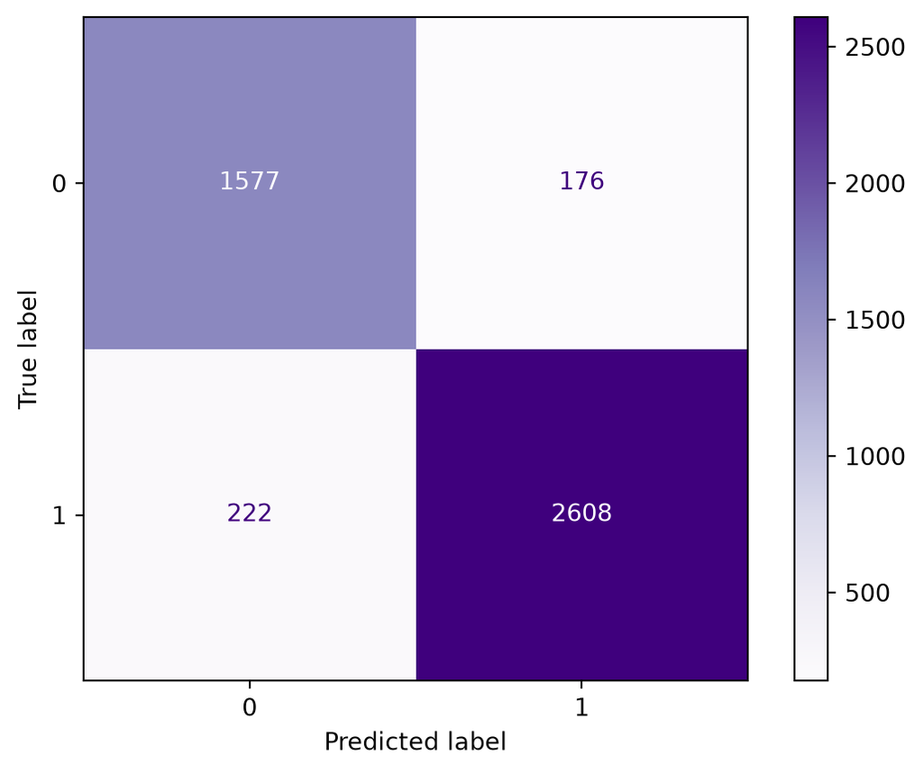

```python
et_classifier = ExtraTreeClassifier(random_state=28)
et_classifier.fit(x_train, y_train)

et_pred = et_classifier.predict(x_test)

print(classification_report(y_test, et_pred))

et_cm=confusion_matrix(y_test, et_pred)
et_disp = ConfusionMatrixDisplay(confusion_matrix = et_cm)

ConfusionMatrixDisplay.from_estimator(et_classifier, x_test, y_test, cmap="Purples")
```

```
              precision    recall  f1-score   support

           0       0.88      0.86      0.87      1753
           1       0.91      0.93      0.92      2830

    accuracy                           0.90      4583
   macro avg       0.90      0.89      0.89      4583
weighted avg       0.90      0.90      0.90      4583
```

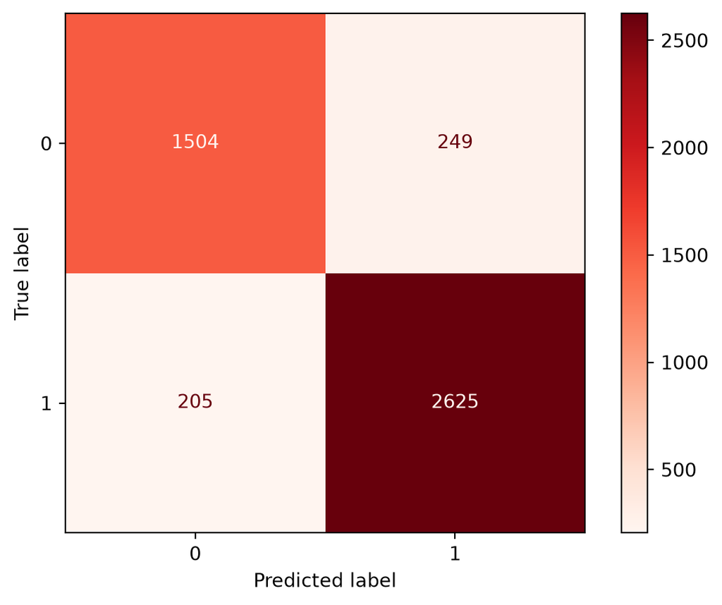

```python
hg_classifier = HistGradientBoostingClassifier(random_state=28)
hg_classifier.fit(x_train, y_train)

hg_pred = hg_classifier.predict(x_test)

print(classification_report(y_test, hg_pred))

hg_cm=confusion_matrix(y_test, hg_pred)
hg_disp = ConfusionMatrixDisplay(confusion_matrix = hg_cm)

ConfusionMatrixDisplay.from_estimator(hg_classifier, x_test, y_test, cmap="Reds")
```

```
              precision    recall  f1-score   support

           0       0.90      0.92      0.91      1753
           1       0.95      0.94      0.94      2830

    accuracy                           0.93      4583
   macro avg       0.92      0.93      0.93      4583
weighted avg       0.93      0.93      0.93      4583
```

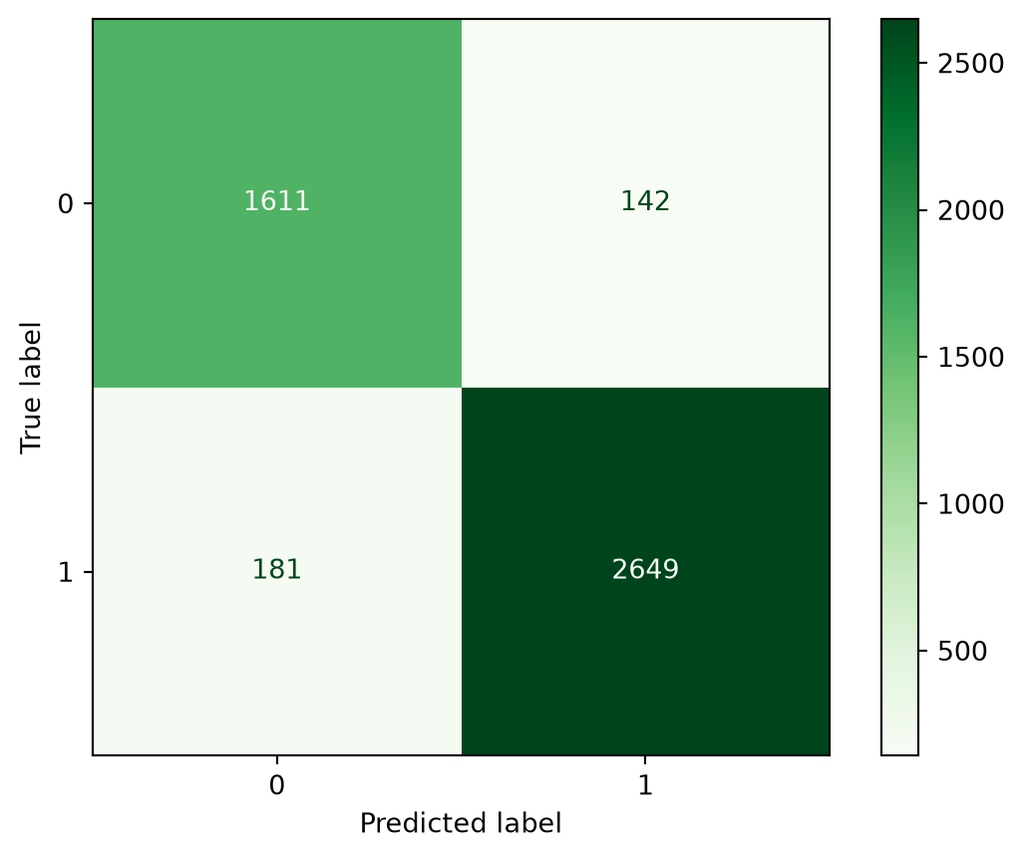

```python
rf_classifier = RandomForestClassifier(n_jobs=-8, random_state=28)
rf_classifier.fit(x_train, y_train)

rf_pred = rf_classifier.predict(x_test)

print(classification_report(y_test, rf_pred))

rf_cm=confusion_matrix(y_test, rf_pred)
rf_disp = ConfusionMatrixDisplay(confusion_matrix = rf_cm)

ConfusionMatrixDisplay.from_estimator(rf_classifier, x_test, y_test, cmap="Greens")
```

## QUESTION 2

1. For each model (your original one, and the 2 new ones for this task), display the classification report and the permutation importances for the most important features. Discuss which model you would recommend to the Client and why.

I would recommend the random forest classifier to the client because it has the highest sscores across the board. In each of precision, recall, and f1-score both the 0 and 1 metrics are the highest of all the models meaning it is the best at guessing correctly when it should, it makes the least false positives, and it is the most accurate.

**Decision Tree Classifier**

```python
# Descision Tree
dt_result= permutation_importance(dt_classifier, x_test, y_test, n_repeats=4,random_state=28)

dt_perms_imp = pl.DataFrame({'importance':dt_result.importances_mean, 'vars':x_train.columns})

print(classification_report(y_test, dt_pred))
print(dt_perms_imp.sort(['importance'], descending=True))
```

```
              precision    recall  f1-score   support

           0       0.88      0.91      0.90      1753
           1       0.94      0.93      0.93      2830

    accuracy                           0.92      4583
   macro avg       0.91      0.92      0.92      4583
weighted avg       0.92      0.92      0.92      4583

shape: (9, 2)
┌────────────┬────────────────────┐
│ importance ┆ vars               │
│ ---        ┆ ---                │
│ f64        ┆ str                │
╞════════════╪════════════════════╡
│ 0.168558   ┆ arcstyle_ONE-STORY │
│ 0.145429   ┆ livearea           │
│ 0.127155   ┆ abstrprd           │
│ 0.122573   ┆ gartype_Att        │
│ 0.103208   ┆ numbaths           │
│ 0.095189   ┆ basement           │
│ 0.080842   ┆ stories            │
│ 0.073696   ┆ quality_C          │
│ 0.062241   ┆ nocars             │
└────────────┴────────────────────┘
```

**Extra Tree Classifier**

```python
# Extra Tree
et_result= permutation_importance(et_classifier, x_test, y_test, n_repeats=4,random_state=28)

et_perms_imp = pl.DataFrame({'importance':et_result.importances_mean, 'vars':x_train.columns})

print(classification_report(y_test, et_pred))
print(et_perms_imp.sort(['importance'], descending=True))
```

```
              precision    recall  f1-score   support

           0       0.88      0.90      0.89      1753
           1       0.94      0.92      0.93      2830

    accuracy                           0.91      4583
   macro avg       0.91      0.91      0.91      4583
weighted avg       0.91      0.91      0.91      4583

shape: (9, 2)
┌────────────┬────────────────────┐
│ importance ┆ vars               │
│ ---        ┆ ---                │
│ f64        ┆ str                │
╞════════════╪════════════════════╡
│ 0.126937   ┆ numbaths           │
│ 0.124209   ┆ abstrprd           │
│ 0.119845   ┆ basement           │
│ 0.108662   ┆ nocars             │
│ 0.107353   ┆ gartype_Att        │
│ 0.105062   ┆ stories            │
│ 0.103262   ┆ livearea           │
│ 0.089297   ┆ arcstyle_ONE-STORY │
│ 0.083242   ┆ quality_C          │
└────────────┴────────────────────┘
```

**Random Forest Classifier**

```python
# Random Forest
rf_result= permutation_importance(rf_classifier, x_test, y_test, n_repeats=4,random_state=28)

rf_perms_imp = pl.DataFrame({'importance':rf_result.importances_mean, 'vars':x_train.columns})

print(classification_report(y_test, rf_pred))
print(rf_perms_imp.sort(['importance'], descending=True))
```

```
              precision    recall  f1-score   support

           0       0.90      0.92      0.91      1753
           1       0.95      0.94      0.94      2830

    accuracy                           0.93      4583
   macro avg       0.92      0.93      0.93      4583
weighted avg       0.93      0.93      0.93      4583

shape: (9, 2)
┌────────────┬────────────────────┐
│ importance ┆ vars               │
│ ---        ┆ ---                │
│ f64        ┆ str                │
╞════════════╪════════════════════╡
│ 0.107953   ┆ gartype_Att        │
│ 0.106153   ┆ stories            │
│ 0.102498   ┆ numbaths           │
│ 0.099444   ┆ basement           │
│ 0.093334   ┆ abstrprd           │
│ 0.089243   ┆ nocars             │
│ 0.088643   ┆ livearea           │
│ 0.071896   ┆ arcstyle_ONE-STORY │
│ 0.068841   ┆ quality_C          │
└────────────┴────────────────────┘
```